# 05-hypothesis testing

# Hypothesis testing

## Introduction

### Why do we test hypotheses?

We test hypotheses because we are confined to taking samples – we rarely work with the entire population. A sample that we take is likely to be different from a second sample that we take from the same population, so we use hypothesis tests to generalize from the sample to the population. However, we need some measure of uncertainty we can assign to analytic results. We use the standard error (i.e., the standard deviation of a large number of hypothetical samples) to gauge how well a particular sample represents the population. This is shown in the following figure.

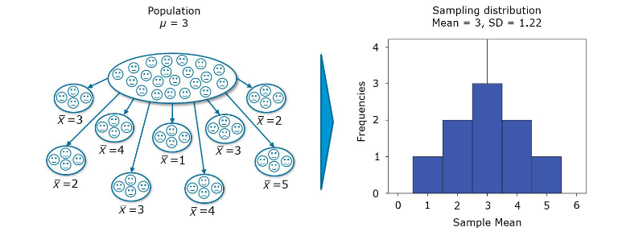

Recall the definition of the standard error (SE):

$$\begin{equation}
\begin{split}
SE = \frac{s}{\sqrt{n}}
\end{split}
(\#eq:SE)
\end{equation}$$

where `s` is the standard deviation and `n` is the number of observations in our sample. If the standard error is low, then we expect most samples to have similar means. If the standard error is large, large differences in sample means are more likely. If the difference in sample means is large, then we would expect based on the standard error that either the collected samples may be atypical of the population, or that the samples come from different populations but are typical of their respective population.

Note that there is a relationship between the sample size and the standard error. The larger the sample size, the smaller the standard error. This can be attributed to the fact that with larger samples, there is less uncertainty that the sample is a good approximation of the entire population.

The following plot shows the relationship between the sample size and the standard error. A hypothetical population of 1,000,000 observations is simulated and samples of ascending size are randomly drawn from this population. You can see that the standard error is decreasing with the number of observations.

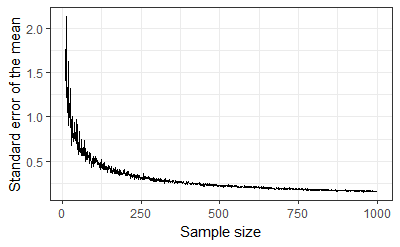

Why is this important? Well, the generalized equation for calculating a test statistic is given by

$$\begin{equation}
\begin{split}
test\ statistic = \frac{effect}{error}
\end{split}
(\#eq:teststatistic)
\end{equation}$$

where `effect` denotes the effect that you are investigating (e.g., the mean difference in an outcome variable between two experimental groups), while `error` denotes the variation we would naturally expect to find based on the variablity in the data and the sample size (e.g., the standard error of the mean difference). When the standard error is lower, the test statistic gets larger and you are more likely to obtain a significant test result. Hence - all else being equal - when you increase your sample size, this will increase the value of your test statistic (i.e., decrease the p-value).

### The process of hypothesis testing

The process of hypothesis testing consists of 6 consecutive steps:

1. Formulate null and alternative hypotheses
2. Select an appropriate test
3. Choose the level of significance (α)
4. Collect data and calculate the test statistic (T<sub>CAL</sub>)
5. Reject or do not reject H<sub>0</sub>
6. Report results and draw a marketing conclusion

In the following, we will use an example to go through the individual steps.

## Parametric tests

The first basic differentiation we can make is between parametric and non-parametric tests.

**Parametric tests** require that variables are measured on an interval or ratio scale and that the data follows a known distribution. Particularly, tests based on the normal distribution (e.g., the t-test) require four basic assumptions:

- A normally distributed sampling distribution
- Interval or ratio data

And in addition for independent tests:

- Scores in different conditions are independent (because they come from different people)
- Homogeneity of variance

**Non-Parametric tests** on the other hand do not require the sampling distribution to be normally distributed (a.k.a. “assumption free tests”). These tests may be used when the variable of interest is measured on an ordinal scale or when the parametric assumptions do not hold. They often rely on ranking the data instead of analyzing the actual scores. By ranking the data, information on the magnitude of differences is lost. Thus, parametric tests are more powerful if the sampling distribution is normally distributed.

### Independent-means t-test

As an example of a parametric test, we will discuss the independent- and dependent-means t-test. The **independent-means t-test** is used when there are two experimental conditions and different units (e.g., participants, products) were assinged to each condition, while the **dependent-means t-test** is used when there are two experimental conditions and the same units (e.g., participants, products) were observed in both experimental conditions.

**Example case:** What is the effect of price promotions on the sales of music albums?

**Experimental setup:** In a music download store, new releases were randomly assigned to an experimental group and sold at a reduced price (i.e., 7.95€), or a control group and sold at the standard price (9.95€). Overall, 102 albums were released on that day and these albums were randomly assinged to the experimental groups (i.e., 51 albums per group). The sales were tracked over one day.

Let’s load and investigate the data first:

```r
library(dplyr)
library(psych)
library(ggplot2)
library(Hmisc)
music_sales <- read.table("https://raw.githubusercontent.com/IMSMWU/Teaching/master/MRDA2017/music_experiment.dat",
                          sep = "\t",
                          header = TRUE) #read in data
music_sales$group <- factor(music_sales$group, levels = c(1:2), labels = c("low_price", "high_price")) #convert grouping variable to factor
str(music_sales) #inspect data
```

```
'data.frame':   102 obs. of  2 variables:
 $ unit_sales: int  6 27 30 24 21 11 18 15 18 13 ...
 $ group     : Factor w/ 2 levels "low_price","high_price": 1 1 1 1 1 1 1 1 1 1 ...
```

```r
head(music_sales) #inspect data
```

|  | unit_sales | group |
| --- | --- | --- |
| 1 | 6 | low_price |
| 2 | 27 | low_price |
| 3 | 30 | low_price |
| 4 | 24 | low_price |
| 5 | 21 | low_price |
| 6 | 11 | low_price |

Inspect frequencies.

```r
table(music_sales$unit_sales, music_sales$group) #frequencies
```

```
     low_price high_price
  0          0          7
  1          0          1
  2          2          4
  3          8         16
  4          4          0
  5          2          0
  6         18          9
  9          3          6
  10         1          0
  11         1          0
  12         3          3
  13         1          0
  15         2          2
  18         2          1
  20         0          1
  21         1          0
  24         1          0
  27         1          0
  30         1          1
```

Inspect descriptives (overall and by group).

```r
psych::describe(music_sales$unit_sales) #overall descriptives
```

```
   vars   n mean   sd median trimmed  mad min max range skew kurtosis   se
X1    1 102 7.12 6.26      6     6.1 4.45   0  30    30 1.71     3.02 0.62
```

```r
describeBy(music_sales$unit_sales, music_sales$group) #descriptives by group
```

```
 Descriptive statistics by group
group: low_price
   vars  n mean   sd median trimmed  mad min max range skew kurtosis  se
X1    1 51 8.37 6.44      6    7.17 4.45   2  30    28 1.66     2.22 0.9
------------------------------------------------------------------------------------------------------------------
group: high_price
   vars  n mean   sd median trimmed  mad min max range skew kurtosis   se
X1    1 51 5.86 5.87      3     4.9 4.45   0  30    30 1.84      4.1 0.82
```

Create boxplot and plot of means.

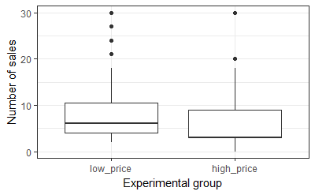

```r
ggplot(music_sales, aes(x = group, y = unit_sales)) +
  geom_boxplot() +
  labs(x = "Experimental group", y = "Number of sales") +
  theme_bw()
```

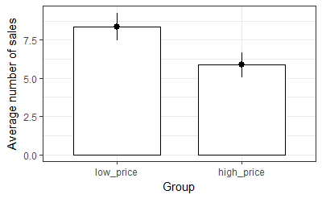

```r
ggplot(music_sales, aes(group, unit_sales)) +
  geom_bar(stat = "summary",  color = "black", fill = "white", width = 0.7) +
  geom_pointrange(stat = "summary") +
  labs(x = "Group", y = "Average number of sales") +
  theme_bw()
```

There appears to be a difference between the two groups. The quesition is: is this difference statstically significant, or would we expect to observe a difference of this magnitude by chance given the sample size and variability in the data?

Let’s test this using a statistical test!

#### Formulate null and alternative hypothesis

What do we mean by null and alternative hypothesis?

**Null Hypothesis (H<sub>0</sub>):**

- Is a statement of the status quo, one of no difference or no effect.
- If the null hypothesis is not rejected, no changes will be made.
- Refers to a specified value of the population parameter (e.g., μ), not a sample statistic, (e.g., $\large\overline{x}$)
- The null hypothesis may be rejected, but it can never be accepted based on a single test. In classical hypothesis testing, there is no way to determine whether the null hypothesis is true.

**Alternative Hypothesis (H<sub>1</sub>):**

- Expects some difference or effect.
- Accepting the alternative hypothesis will lead to changes in opinions or actions.
- Rejection of null hypothesis is taken as support for the experimental / alternative hypothesis.

Furthermore, we can differentiate between directional and non-directional hypotheses:

**Directional hypothesis:**

- States the direction of the effect.
- Leads to a **one-tailed test**:

$H_0: \mu_1 \le \mu_2$  
$H_1: \mu_1 > \mu_2$

Example: the mean sales of albums sold at 7.95€ are higher than the mean sales of albums sold at 9.95€.

**Non-directional hypothesis:**

- States that an effect will occur, but it does not state the direction of the effect.
- Leads to a **two-tailed test**:

$H_0: \mu_1 = \mu_2$  
$H_1: \mu_1 \neq \mu_2$

In our example, a non-directional hypothesis would be appropriate. The reason is that we cannot be 100% certain about the direction that the effect might take. For example, although it might seem plausible that lower prices might lead to higher sales, it is also possible that price is perceived as a quality signal, making a product less attractive for certain consumer segments.

⚡ Rejecting the null hypothesis does not prove the alternative hypothesis (we can merely provide support for it). Rather, think of it as the chance of obtaining the data we’ve collected assuming that the null hypothesis is true.

#### Select an appropriate test

We fit a statistical model to the data in order to make predictions about the real world phenomenon. The test statistic measures how close the sample is to the null hypothesis. The test statistic often follows a well-known distribution (e.g., normal, t, or chi-square). To select the correct test, various factors need to be taken into consideration. Some examples are:

- On what scale are your variables measured (categorical vs. continuous)?
- Do you want to test for relationships or differences?
- If you test for differences, how many groups would you like to test?
- For parametric tests, are the assumptions fulfilled?

The following flow chart provides a rough guideline on selecting the correct test:

[figure not shown]

For a detailed overview of the different type of tests, please also refer to [this overview](https://stats.idre.ucla.edu/other/mult-pkg/whatstat/) by the UCLA.

In the present example, the t-test is appropriate since we would like to test for differences between two means of a single continuous variable (sales).

Properties of the t-distribution:

- Adequate when the mean for a normally distributed variable is estimated (Student’s t-distribution).
- Assumes that the mean is known and that the population variance is estimated from a normally distributed sample.
- The t-distribution is similar to the normal distribution in appearance (bell-shaped and symmetric).
- As the number of degrees of freedom increases, the t-distribution approaches the normal distribution.

To see this, the following graph shows the t-distribution with different degrees of freedom for a two-tailed test and α = 0.05.

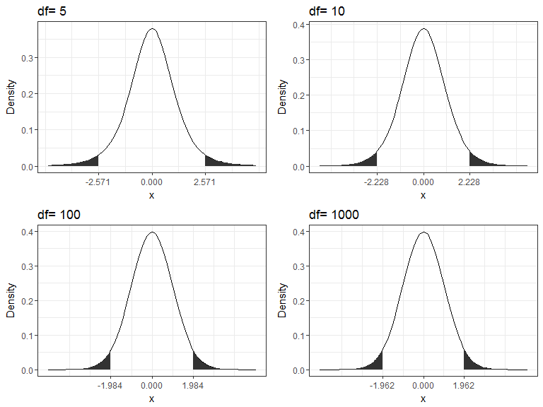

You can see that the critical value (T<sub>CR</sub>) decreases as the degrees of freedom increase. This is due to the fact that larger degrees of freedom mean that you have more information available relative to the number of parameters that you would like to estimate.

Connected to the decision on how to phrase the hypotheses (directional vs. non-directional) is the choice of a one-tailed versus a two-tailed test. Let’s first think about the meaning of a one-tailed test. Using a significance level of 0.05, a one-tailed test means that 5% of the total area under the probability distribution of our test statistic is located in one tail. Thus, under a one-tailed test, we test for the possibility of the relationship in one direction only, disregarding the possibility of a relationship in the other direction. In our example, a one-tailed test will test either if the mean sales level in the experimental condition is significantly larger or smaller compared to the control condition, but not both. Depending on the direction, the mean sales level of the experimental group is significantly larger (smaller) if the test statistic is located in the top (bottom) 5% of its probability distribution, resulting in a p-value smaller than 0.05.

In our example, we used a non-directional hypothesis, meaning that a two-sided test is appropriate. Nevertheless, let’s consider the consequences of using a directional hypothesis (one-sided test). If we assume a positive effect of price promotion on sales (reducing the price leads to higher sales), then we would expect the mean sales in the experimental group to be larger compared to the control group and, thus, derive a positive test statistic. Imagine a scenario where we need a test statistic bigger than 1.66 to find a significant effect at the 5% level under a directional hypothesis, but the test-statistic we get is actually -2.1. In this case, we would retain the null hypothesis although an effect exists and could have been detected using a two-sided test. So unless you consider the consequences of missing an effect in the untested direction negligible, you should use a two-sided test (non-directional hypothesis).

Now we need to make a decision between the independent and the dependent t-test. As stated above, the independent-means t-test is used when there are two experimental conditions and different units were assinged to each condition, while the dependent-means t-test is used when there are two experimental conditions and the same units were observed in both conditions of the experiment. In our example, the **independent-means t-test** is appropriate since different music albums were randomly assigned to both experimental conditions.

Finally, let’s test if the assumptions of the chosen test are fullfilled:

- A normally distributed sampling distribution (✔ - we can assume this since n > 30 per group)
- Interval or ratio data (✔ - sales is on a ratio scale)
- Scores in different conditions are independent (✔ - products were randomly assigned)
- Homogeneity of variance: you don’t have to worry about this assumption too much for three reasons: 1) violating this assumption only really matters if you have unequal group sizes - in our context, we have equal group sizes (n = 51 per group); 2) even if this assumption is violated, there is an adjustment (called Welch’s t-test) which corrects for unequal variances and this is easily implemented in R (actually, it is the default setting); 3) the tests for homogeneity of variances tend to work better when group sizes are equal and samples are large (which is when we don’t need it), and not so well with unequal group sizes and smaller samples (which is when you actually need it).